# Sentiment Analysis and Intro to Twitter API

Iv'e been looking for a reason to play around with sentiment analysis for a while now and looking at our presidents tweets, I got curious if he was an overly negative president, using data of course ;)

So in this notebook I'll use the twitter api to look at tweets using the `python-twitter` package and `textblob` package to do some simple sentiment analysis.

Before starting to use the twitter API you'll need to set up keys and access tokens for [twitter](https://apps.twitter.com/). Make sure to keep these secret and don't commit to github!

Let's start off by importing twitter, textblob, and matplotlib.

## Boiler plate

```python
import datetime
import re
import seaborn as sns
import twitter
from textblob import TextBlob
import pylab as p
import pandas as pd
% matplotlib inline
sns.set_palette('hls')
```

Now we also set up the twitter api class using your twitter keys.

```python
consumer_key = 'your_consumer_key'
consumer_secret = 'your_consumer_secret'
token = 'your_token'
token_secret = 'your_token_secret'

api = twitter.Api(consumer_key=consumer_key,
                  consumer_secret=consumer_secret,
                  access_token_key=token,
                  access_token_secret=token_secret)
```

```python
def create_tweet_df(tweets):

    tweet_dict = {'created_at': [],
                  'favorite_count': [],
                  'hashtags': [],
                  'id': [],
                  'expanded_url': [],
                  'tweet': []}
    for ut in tweets:
        tweet_dict['tweet'].append((ut.text))
        tweet_dict['created_at'].append(ut.created_at)
        try:
            tweet_dict['hashtags'].append(','.join(ht.text for ht in ut.hashtags))
        except KeyError:
            tweet_dict['hashtags'].append('')
        tweet_dict['id'].append(ut.id)
        try:
            tweet_dict['expanded_url'].append(','.join(url.expanded_url for url in ut.urls))
        except KeyError:
            tweet_dict['expanded_url'].append('')
        tweet_dict['favorite_count'].append(ut.favorite_count)

    df = pd.DataFrame(tweet_dict)
    return df


def remove_links(tweet):
    link_pattern = re.compile(r"(?:\@|https?\://)\S+")
    return link_pattern.sub(r'', tweet)


def remove_emojis(tweet):
    emoji_pattern = re.compile(
                               u"(\ud83d[\ude00-\ude4f])|"  # emoticons
                               u"(\ud83c[\udf00-\uffff])|"  # symbols & pictographs (1 of 2)
                               u"(\ud83d[\u0000-\uddff])|"  # symbols & pictographs (2 of 2)
                               u"(\ud83d[\ude80-\udeff])|"  # transport & map symbols
                               u"(\ud83c[\udde0-\uddff])"  # flags (iOS)
                               "+", flags=re.UNICODE)
    return emoji_pattern.sub(r'', tweet)


def get_tweets(api, screen_name, total_count=200):
    Ntweets = total_count
    user_tweets = []
    uts = api.GetUserTimeline(screen_name=screen_name, count=200)
    user_tweets.extend(uts)
    maxid = uts[-1].id

    count = 200
    while count < Ntweets:
        uts = api.GetUserTimeline(screen_name=screen_name, count=200, max_id=maxid)
        user_tweets.extend(uts)
        maxid = uts[-1].id
        count += 200
    return user_tweets
```

## Getting the tweets

Now lets get the most recent 1000 tweets from the user "realDonaldTrump". To do this we use the GetUserTimeline attribute. The API call returns a Status object which has a bunch of meta information in addition to the tweet text such as the date it was created, the hashtags used, etc.

Note that the call only returns the 200 most recent tweets so have to do some extra work to get 1000 tweets.

Above we created a function to create a pandas dataframe and we then parse the tweets to remove links and emojis.

```python
user_tweets = get_tweets(api, 'realDonaldTrump', total_count=1000)
tweet_frame = create_tweet_df(user_tweets)

tweet_frame.tweet = tweet_frame.tweet.apply(remove_links)
tweet_frame.tweet = tweet_frame.tweet.apply(remove_emojis)
tweet_frame.created_at = tweet_frame.created_at.apply(lambda x: datetime.datetime.strptime(x, '%a %b %d %H:%M:%S +0000 %Y'))
```

```python
tweet_frame.head()
```

|  | created_at | expanded_url | favorite_count | hashtags | id | tweet |
| --- | --- | --- | --- | --- | --- | --- |
| 0 | 2017-10-28 23:15:39 |  | 25219 |  | 924414387343028224 | JFK Files are released, long ahead of schedule! |
| 1 | 2017-10-28 22:19:42 |  | 39714 |  | 924400308834455552 | While not at all presidential I must point out... |
| 2 | 2017-10-28 22:08:30 | https://twitter.com/i/web/status/9243974890374... | 21396 | FirstRespondersDay | 924397489037430784 | Happy #FirstRespondersDay to all of our HEROES... |
| 3 | 2017-10-28 21:10:36 |  | 27600 |  | 924382919845666816 | ...in order to put any and all conspiracy theo... |
| 4 | 2017-10-28 21:09:57 |  | 25472 |  | 924382752941756421 | ...addresses of any mentioned person who is st... |

The tweets are cleaned up we can now get the sentiment polarity and subjectivity of the tweet and do some simple analysis. This is incredibly easy using TextBlob. The polarity ranges from -1.0 to 1.0 where values less than zero have a negative connotation and values greater than zero have a positive connotation. Subjectivity ranges from 0 to 1 with 0 being very objective and 1 being very subjective.

```python
tweet_frame['sentiment'] = tweet_frame['tweet'].apply(lambda x: TextBlob(x).polarity)
tweet_frame['subjectivity'] = tweet_frame['tweet'].apply(lambda x: TextBlob(x).subjectivity)
```

## A look at the Data

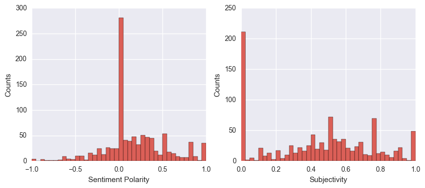

```python
p.figure(figsize=(10,4))
p.subplot(121)
tweet_frame.sentiment.hist(bins=40)
p.ylabel('Counts')
p.xlabel('Sentiment Polarity')
p.subplot(122)
tweet_frame.subjectivity.hist(bins=40)
p.ylabel('Counts')
p.xlabel('Subjectivity')
```

So out of the past 1000 tweets from @realDonaldTrump, it looks like about a third are neutral and a large around 50% are positive, while around 25% are negative sentiments. Similarily a lot of the tweets are objective, but a few are highly subjective. Is this a cause for concern? Probably.

## compare to potus

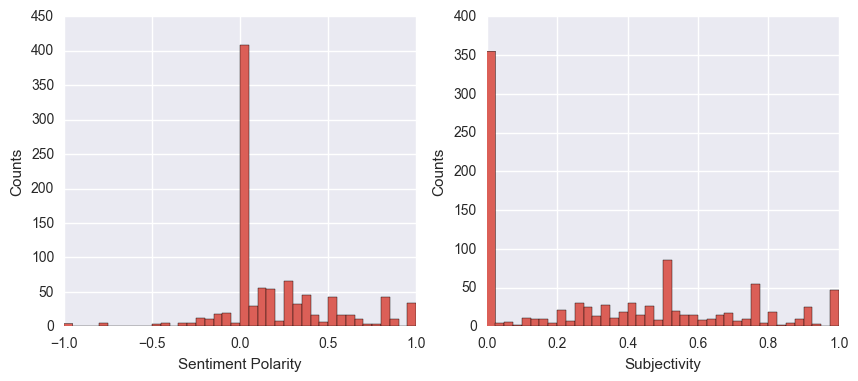

```python
user_tweets_potus = get_tweets(api, 'potus', total_count=1000)
tweet_frame_potus = create_tweet_df(user_tweets_potus)

tweet_frame_potus.tweet = tweet_frame_potus.tweet.apply(remove_links)
tweet_frame_potus.tweet = tweet_frame_potus.tweet.apply(remove_emojis)
tweet_frame_potus.created_at = tweet_frame_potus.created_at.apply(lambda x: datetime.datetime.strptime(x, '%a %b %d %H:%M:%S +0000 %Y'))

tweet_frame_potus['sentiment'] = tweet_frame_potus['tweet'].apply(lambda x: TextBlob(x).polarity)
tweet_frame_potus['subjectivity'] = tweet_frame_potus['tweet'].apply(lambda x: TextBlob(x).subjectivity)

p.figure(figsize=(10,4))
p.subplot(121)
tweet_frame_potus.sentiment.hist(bins=40)
p.ylabel('Counts')
p.xlabel('Sentiment Polarity')
p.subplot(122)
tweet_frame_potus.subjectivity.hist(bins=40)
p.ylabel('Counts')
p.xlabel('Subjectivity')
```

Looks like @potus is not as bad as @realDonaldTrump with a larger fraction being positive or neutral tweets.